# 002-ode-day2

Euler is approximation of solution, Uniqueness and readiness of solution

Ecistence of solutions [Peano] If the right hand side [RHS] f(t,u) of an ODE is continuous then for given initial value (to, Uo) A solution exist for "sometime". and it is continuous.

The thoeory is clear in ode but in pde we have to search all solution.

*only continuous is not enogh*

Two BAD things can happen

1. Blow up in final time.
2. Solution is not unique

## 1. Blow-up in finite time

Example: $\;u'(t) = u(t)^2, \quad u(0) = u_0 > 0$

The right-hand side $f(t,u) = u^2$ is continuous (even $C^\infty$), so **Peano** guarantees a solution for *some* time. How long? Separate variables:

$$\frac{du}{u^2} = dt \;\Rightarrow\; -\frac{1}{u} = t + C \;\Rightarrow\; u(t) = \frac{1}{1/u_0 - t} = \frac{u_0}{1 - u_0 t}$$

The denominator hits zero at the **blow-up time** $t^* = 1/u_0$. With $u_0 = 1$: the solution exists only on $[0, 1)$ and $u(t) \to \infty$ as $t \to 1^-$.

Nothing in $f$ warns you — "some time" in Peano's theorem really means *some* time.

```python
import numpy as np
import matplotlib.pyplot as plt
```

```python
def f(t, u):
    return u**2

u0 = 1.0
t_star = 1.0 / u0                 # blow-up time

def u_exact(t):
    return u0 / (1.0 - u0 * t)

print(f"blow-up time t* = {t_star}")
```

```
blow-up time t* = 1.0
```

```python
def euler(f, t0, u0, h, T):
    """explicit Euler from t0 to T with step h; returns arrays t, y"""
    N = int(round((T - t0) / h))
    t_values = [t0]
    y_values = [u0]
    t, y = t0, np.float64(u0)      # numpy float: overflows to inf instead of raising
    for i in range(N):
        y = y + h * f(t, y)
        t = t + h
        t_values.append(t)
        y_values.append(y)
    return np.array(t_values), np.array(y_values)
```

```python
# integrate up to T just before the blow-up time
T = 0.99

for h in [0.1, 0.05, 0.01, 0.001]:
    t, y = euler(f, 0.0, u0, h, T)
    print(f"h = {h:<6}  Euler y(T) = {y[-1]:12.3f}   exact u(T) = {u_exact(T):.1f}")
```

```
h = 0.1     Euler y(T) =        6.129   exact u(T) = 100.0
h = 0.05    Euler y(T) =        9.553   exact u(T) = 100.0
h = 0.01    Euler y(T) =       24.424   exact u(T) = 100.0
h = 0.001   Euler y(T) =       70.324   exact u(T) = 100.0
```

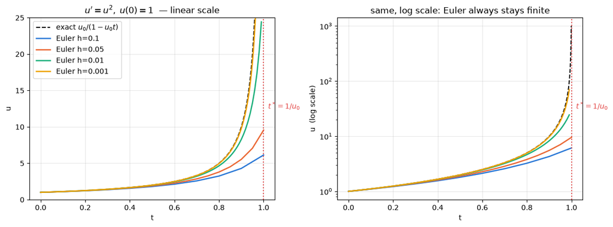

```python
fig, (ax1, ax2) = plt.subplots(1, 2, figsize=(12, 4.5))

tt = np.linspace(0, 0.999, 2000)
colors = ["#2a78d6", "#eb6834", "#1baf7a", "#eda100"]      # fixed order per h

for ax in (ax1, ax2):
    ax.plot(tt, u_exact(tt), "k--", lw=1.5, label=r"exact $u_0/(1-u_0 t)$")
    for h, c in zip([0.1, 0.05, 0.01, 0.001], colors):
        t, y = euler(f, 0.0, u0, h, T)
        ax.plot(t, y, color=c, lw=1.8, label=f"Euler h={h}")
    ax.axvline(t_star, color="#e34948", ls=":", lw=1.5)
    ax.text(t_star, 0.5, r"  $t^* = 1/u_0$", color="#e34948", transform=ax.get_xaxis_transform())
    ax.set_xlabel("t")
    ax.grid(alpha=0.3)

ax1.set_ylim(0, 25)
ax1.set_ylabel("u")
ax1.set_title("$u' = u^2,\; u(0)=1$  — linear scale")
ax1.legend(loc="upper left")

ax2.set_yscale("log")
ax2.set_ylabel("u  (log scale)")
ax2.set_title("same, log scale: Euler always stays finite")

plt.tight_layout()
plt.show()
```

### What the plot shows

- The **exact** solution leaves every bound before $t = 1$ — it does not exist at $t^* = 1$ or beyond.
- **Euler never blows up.** Each step $y_{k+1} = y_k + h\,y_k^2$ is a finite number, so the numerical solution *cannot* see the singularity — it just lags further and further behind the exact curve (Euler follows the tangent, and the tangent underestimates a convex, growing solution).
- Only by refining $h$ do you notice that the values near $t^*$ keep growing without bound — the hint that something is wrong with the model, not the method.

### Euler happily continues *past* the blow-up

If you don't know $t^*$ and just integrate to $T = 1.5$, Euler returns numbers — nonsense numbers.

```python
np.seterr(over="ignore")           # let it overflow to inf instead of warning

for h in [0.1, 0.01, 0.001]:
    t, y = euler(f, 0.0, u0, h, 1.5)
    first_inf = f"{t[np.isinf(y)][0]:.3f}" if np.any(np.isinf(y)) else "never (yet)"
    print(f"h = {h:<6}  y(1.0) = {y[np.argmin(abs(t-1.0))]:>10.4g}   y(1.5) = {y[-1]:>10.4g}   first inf at t = {first_inf}")
```

```
h = 0.1     y(1.0) =      6.129   y(1.5) =  1.625e+04   first inf at t = never (yet)
h = 0.01    y(1.0) =      30.39   y(1.5) =        inf   first inf at t = 1.140
h = 0.001   y(1.0) =      193.1   y(1.5) =        inf   first inf at t = 1.017
```

**Take-away:** a continuous $f$ gives you existence *locally*; to get a solution on a whole interval you need more (e.g. $f$ Lipschitz + linear growth bound). That's the next theorem — Picard–Lindelöf — which also fixes bad thing #2 (uniqueness).

## 2. Lipschitz continuity — the condition that fixes both "bad things"

**Definition.** $f$ is *Lipschitz continuous in $u$* with constant $L$ if

$$|f(t,u) - f(t,v)| \le L\,|u - v| \qquad \text{for all } u, v.$$

In words: the slope of every secant is at most $L$ — the function can't be steeper than $L$ anywhere. If $f$ is differentiable this is the same as $|\partial_u f| \le L$.

| right-hand side | Lipschitz? | consequence |
| --- | --- | --- |
| $f = u$ (exponential) | ✅ globally, $L = 1$ | unique solution for all $t$ |
| $f = u^2$ (blow-up above) | ⚠️ only locally — $f' = 2u$ unbounded | unique, but only for $t < 1/u_0$ |
| $f = \sqrt{u}$, $u(0) = 0$ | ❌ not even locally — $f' = \tfrac{1}{2\sqrt u} \to \infty$ | **not unique**: $u \equiv 0$ and $u = t^2/4$ both solve it |

- **Peano:** $f$ continuous → a solution exists for *some* time. No uniqueness.
- **Picard–Lindelöf:** $f$ Lipschitz in $u$ → existence **and uniqueness** (locally). Add a linear growth bound $|f| \le a + b|u|$ → existence for **all** time (no blow-up).

**Why Lipschitz gives uniqueness (Grönwall in one line).** Two solutions $u, v$ with the same initial value, $d(t) = |u - v|$: $$d' \le |f(t,u) - f(t,v)| \le L\,d \;\Rightarrow\; d(t) \le d(0)\,e^{Lt} = 0.$$ The gap can grow at most exponentially — and it starts at zero. The same estimate is what bounds the accumulation of Euler's errors (Section 4).

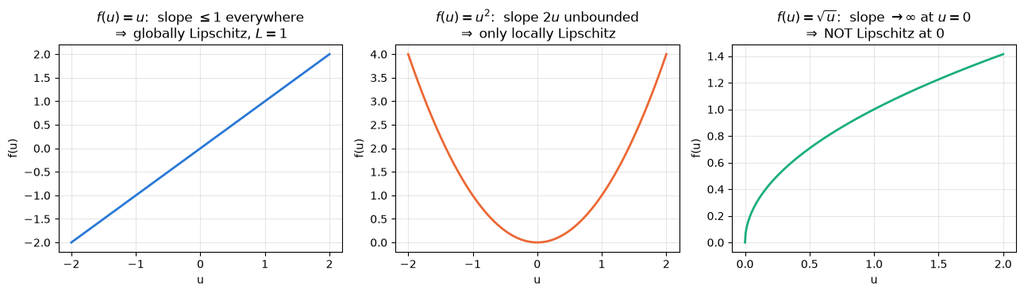

```python
# ---------------------------------------------------------------------------
# 1. What Lipschitz means: |f(u) - f(v)| <= L |u - v|   (slope never exceeds L)
# ---------------------------------------------------------------------------
u = np.linspace(-2, 2, 400)
u_pos = np.linspace(0, 2, 400)

fig, ax = plt.subplots(1, 3, figsize=(13, 3.8))

ax[0].plot(u, u, color="#2a78d6", lw=2)
ax[0].set_title(r"$f(u)=u$:  slope $\leq 1$ everywhere" "\n" r"$\Rightarrow$ globally Lipschitz, $L=1$")

ax[1].plot(u, u**2, color="#eb6834", lw=2)
ax[1].set_title(r"$f(u)=u^2$:  slope $2u$ unbounded" "\n" r"$\Rightarrow$ only locally Lipschitz")

ax[2].plot(u_pos, np.sqrt(u_pos), color="#1baf7a", lw=2)
ax[2].set_title(r"$f(u)=\sqrt{u}$:  slope $\rightarrow\infty$ at $u=0$" "\n" r"$\Rightarrow$ NOT Lipschitz at 0")

for a in ax:
    a.set_xlabel("u"); a.set_ylabel("f(u)"); a.grid(alpha=0.3)
plt.tight_layout()
plt.show()
```

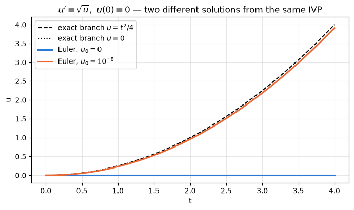

```
u(4) from u0 = 0     : 0.0000
u(4) from u0 = 1e-8  : 3.9103   (exact t^2/4 = 4.0000)
```

```python
# 2. Consequence: without Lipschitz the solution is NOT unique
#    u' = sqrt(u), u(0) = 0   has  u = 0  AND  u = t^2/4  (and infinitely many more)
# ---------------------------------------------------------------------------
def euler(f, u0, h, T):
    """explicit Euler for u' = f(u), u(0) = u0"""
    N = int(round(T / h))
    t, y = 0.0, np.float64(u0)
    t_values, y_values = [t], [y]
    for i in range(N):
        y = y + h * f(y)
        t = t + h
        t_values.append(t); y_values.append(y)
    return np.array(t_values), np.array(y_values)

f = np.sqrt
h, T = 0.01, 4.0

t, y_zero = euler(f, 0.0,  h, T)      # exactly zero start  -> stays on u = 0
t, y_eps  = euler(f, 1e-8, h, T)      # invisible perturbation -> jumps to the other branch

fig, ax = plt.subplots(figsize=(7, 4.2))
ax.plot(t, t**2 / 4, "k--", lw=1.5, label=r"exact branch $u = t^2/4$")
ax.plot(t, 0 * t,    "k:",  lw=1.5, label=r"exact branch $u \equiv 0$")
ax.plot(t, y_zero, color="#2a78d6", lw=2.2, label=r"Euler, $u_0 = 0$")
ax.plot(t, y_eps,  color="#eb6834", lw=2.2, label=r"Euler, $u_0 = 10^{-8}$")
ax.set_xlabel("t"); ax.set_ylabel("u")
ax.set_title(r"$u' = \sqrt{u},\ u(0)=0$ — two different solutions from the same IVP")
ax.legend(); ax.grid(alpha=0.3)
plt.tight_layout()
plt.show()

print(f"u(4) from u0 = 0     : {y_zero[-1]:.4f}")
print(f"u(4) from u0 = 1e-8  : {y_eps[-1]:.4f}   (exact t^2/4 = {T**2/4:.4f})")
```

```python
# 3. With Lipschitz, nearby solutions stay nearby:  |u - v|(t) <= |u0 - v0| e^{Lt}
#    u' = u  (L = 1): a 1e-8 perturbation stays ~1e-8 * e^t  -> uniqueness
# ---------------------------------------------------------------------------
t, a = euler(lambda u: u, 1.0,        h, T)
t, b = euler(lambda u: u, 1.0 + 1e-8, h, T)
print(f"\nu' = u : gap at t=0 = 1e-8, gap at t=4 = {abs(b[-1]-a[-1]):.2e}  (bound e^4 * 1e-8 = {np.e**4*1e-8:.2e})")
```

```
u' = u : gap at t=0 = 1e-8, gap at t=4 = 5.35e-07  (bound e^4 * 1e-8 = 5.46e-07)
```

**What to see.** Same IVP $u' = \sqrt u$, $u(0) = 0$: Euler from exactly $0$ stays $0$; from $10^{-8}$ it climbs to $t^2/4$. Both are genuine solutions — an invisible perturbation decides which one you get. For $u' = u$ (Lipschitz) the $10^{-8}$ gap stays $\le 10^{-8} e^{Lt}$: measured $5.35\times10^{-7}$ vs bound $5.46\times10^{-7}$ at $t = 4$.

## 3. Explanation: why the Euler amplitude grows (Day-1 plot)

System (*): $\;u_1' = u_2,\quad u_2' = -u_1$

**Exact solution conserves energy.** $E = u_1^2 + u_2^2$ is constant along solutions: $$(u_1^2 + u_2^2)' = 2u_1 u_1' + 2u_2 u_2' = 2u_1 u_2 + 2u_2(-u_1) = 0 \qquad(\sin^2 t + \cos^2 t = 1)$$

**Euler for (*):** $(y_1, y_2) \longrightarrow (y_1 + h y_2,\; y_2 - h y_1)$ $$(y_1 + h y_2)^2 + (y_2 - h y_1)^2 = y_1^2 + 2h y_1 y_2 + h^2 y_2^2 + y_2^2 - 2h y_1 y_2 + h^2 y_1^2 = (1 + h^2)(y_1^2 + y_2^2)$$

The cross terms cancel: **every Euler step multiplies the energy by $(1+h^2) > 1$**, wherever you are. After $N = T/h$ steps $$E_N = (1+h^2)^N E_0 = (1+h^2)^{T/h} E_0 \approx e^{hT} E_0 .$$ Day-1 run ($h = 0.02$, $N = 500$): $E_N = 1.0004^{500} = 1.2214$, amplitude $\times\sqrt{1.2214} = 1.105$ — the outward spiral. $N = 100$, $h = 0.1$: $(1.01)^{100} = 2.70 \approx e$.

Geometrically: Euler follows the tangent to the circle, which always lands *outside* it. Two fixes:

- **implicit Euler** $y^{n+1} = y^n + h f(y^{n+1})$: energy $\times\frac{1}{1+h^2}$ per step — spirals *inward*;
- **symplectic Euler**: update $y_1$ with the old $y_2$, then $y_2$ with the *new* $y_1$ — energy stays bounded forever.

```
explicit Euler:  E_N = 1.2214   (1+h²)^N = 1.2214   e^(hT) = 1.2214
implicit Euler:  E_N = 0.8188   (1+h²)^-N = 0.8188
symplectic:      E stays in [0.9901, 1.0101]  — bounded, no drift
```

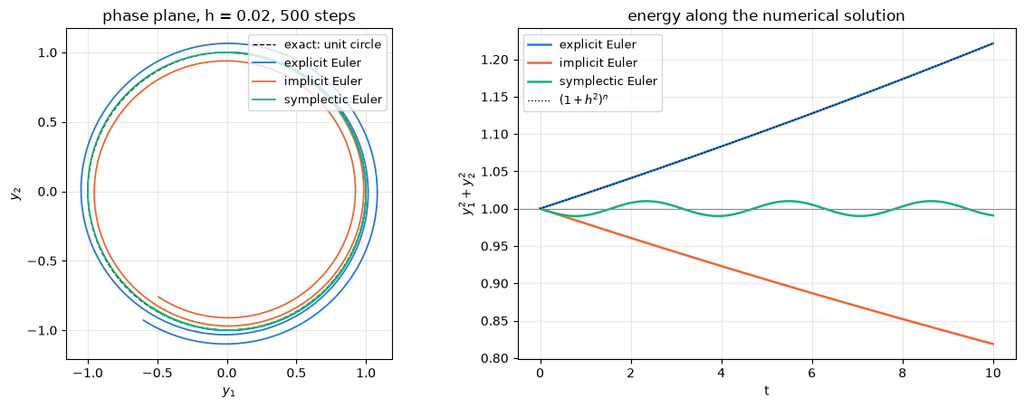

```python
h, N = 0.02, 500                                    # Day-1 settings: T = 10

# three one-step methods for  u1' = u2,  u2' = -u1
def explicit_euler(y1, y2):   return y1 + h * y2, y2 - h * y1
def implicit_euler(y1, y2):                          # solve the 2x2 linear system exactly
    return (y1 + h * y2) / (1 + h**2), (y2 - h * y1) / (1 + h**2)
def symplectic_euler(y1, y2):
    y1_new = y1 + h * y2                             # update y1 with the OLD y2 ...
    return y1_new, y2 - h * y1_new                   # ... then y2 with the NEW y1

def run(step):
    y1, y2 = 0.0, 1.0
    Y = [(y1, y2)]
    for n in range(N):
        y1, y2 = step(y1, y2); Y.append((y1, y2))
    return np.array(Y)

t = h * np.arange(N + 1)
runs = {"explicit Euler": (run(explicit_euler), "#2a78d6"),
        "implicit Euler": (run(implicit_euler), "#eb6834"),
        "symplectic Euler": (run(symplectic_euler), "#1baf7a")}

# energy check against the formula
E_exp = (runs["explicit Euler"][0]**2).sum(axis=1)
print(f"explicit Euler:  E_N = {E_exp[-1]:.4f}   (1+h²)^N = {(1+h**2)**N:.4f}   e^(hT) = {np.exp(h*N*h):.4f}")
print(f"implicit Euler:  E_N = {(runs['implicit Euler'][0][-1]**2).sum():.4f}   (1+h²)^-N = {(1+h**2)**-N:.4f}")
E_sym = (runs["symplectic Euler"][0]**2).sum(axis=1)
print(f"symplectic:      E stays in [{E_sym.min():.4f}, {E_sym.max():.4f}]  — bounded, no drift")

fig, (ax1, ax2) = plt.subplots(1, 2, figsize=(12, 4.6))
th = np.linspace(0, 2 * np.pi, 300)
ax1.plot(np.cos(th), np.sin(th), "k--", lw=1, label="exact: unit circle")
for name, (Y, c) in runs.items():
    ax1.plot(Y[:, 0], Y[:, 1], color=c, lw=1.3, label=name)
ax1.set_aspect("equal"); ax1.set_xlabel("$y_1$"); ax1.set_ylabel("$y_2$")
ax1.set_title(f"phase plane, h = {h}, {N} steps"); ax1.legend(fontsize=9, loc="upper right"); ax1.grid(alpha=0.3)

for name, (Y, c) in runs.items():
    ax2.plot(t, (Y**2).sum(axis=1), color=c, lw=1.8, label=name)
ax2.plot(t, (1 + h**2)**np.arange(N + 1), "k:", lw=1, label=r"$(1+h^2)^n$")
ax2.axhline(1, color="#8a8984", lw=0.8)
ax2.set_xlabel("t"); ax2.set_ylabel("$y_1^2 + y_2^2$"); ax2.set_title("energy along the numerical solution")
ax2.legend(fontsize=9); ax2.grid(alpha=0.3)
plt.tight_layout(); plt.show()
```

## 4. Local and global error — order of a method

**Def (one-step method).** The next iterate is produced by $$y_{n+1} = y_n + h\,\Phi(t_n, y_n, h)$$ ($\Phi$ = increment function; Euler: $\Phi = f(t_n, y_n)$; Heun: $\Phi = \tfrac12\big(f(t_n,y_n) + f(t_n + h,\, y_n + h f(t_n,y_n))\big)$).

**Def (local error).** One step started from the **exact** solution: $$\hat y_{n+1} = u(t_n) + h\,\Phi(t_n, u(t_n), h), \qquad \text{local error} = \|u(t_{n+1}) - \hat y_{n+1}\|$$

**Def (global error).** Error of the whole march from $t_0$: $\;\|u(t_n) - y_n\|$.

**Def (order).** The method has order $p$ if the global error satisfies $\|y_N - u(T)\| \approx C\,h^p$ ($N = T/h$). Equivalently the local error is $O(h^{p+1})$: $N = T/h$ steps of size $h^{p+1}$ accumulate (amplified by at most $e^{LT}$, Grönwall) to $h^p$.

| method | local | global | order |
| --- | --- | --- | --- |
| Euler | $O(h^2)$, constant $\tfrac12\\|u''\\|$ | $O(h)$ | 1 |
| Heun (RK2) | $O(h^3)$ | $O(h^2)$ | 2 |

```python
# ============================================================================
# 2.1  LOCAL AND GLOBAL ERROR of a one-step method   y_{n+1} = y_n + h * Phi(t_n, y_n, h)
# ============================================================================

# ---- test problem: the sin–cos system, exact solution known ----------------
def f(t, u):
    return np.array([u[1], -u[0]])            # u1' = u2,  u2' = -u1

def u_exact(t):
    return np.array([np.sin(t), np.cos(t)])

u0 = np.array([0.0, 1.0])

# ---- one-step methods, written as increment functions Phi ------------------
def Phi_euler(f, t, y, h):
    return f(t, y)

def Phi_heun(f, t, y, h):                     # improved Euler / RK2, for comparison
    k1 = f(t, y)
    k2 = f(t + h, y + h * k1)
    return 0.5 * (k1 + k2)

def one_step(Phi, f, t, y, h):
    return y + h * Phi(f, t, y, h)

# ---- LOCAL error:  || u(t_{n+1}) - y_hat_{n+1} ||,  y_hat from the EXACT u(t_n)
def local_errors(Phi, f, u_exact, h, T):
    t = np.arange(0.0, T + 1e-12, h)
    err = []
    for tn in t[:-1]:
        y_hat = one_step(Phi, f, tn, u_exact(tn), h)      # start on the exact curve
        err.append(np.linalg.norm(u_exact(tn + h) - y_hat))
    return t[1:], np.array(err)

# ---- GLOBAL error: || u(t_n) - y_n ||,  y_n from the whole march since t_0
def global_errors(Phi, f, u_exact, u0, h, T):
    N = int(round(T / h))
    t, y = 0.0, u0.copy()
    ts, err = [0.0], [0.0]
    for n in range(N):
        y = one_step(Phi, f, t, y, h)
        t = t + h
        ts.append(t); err.append(np.linalg.norm(u_exact(t) - y))
    return np.array(ts), np.array(err)
```

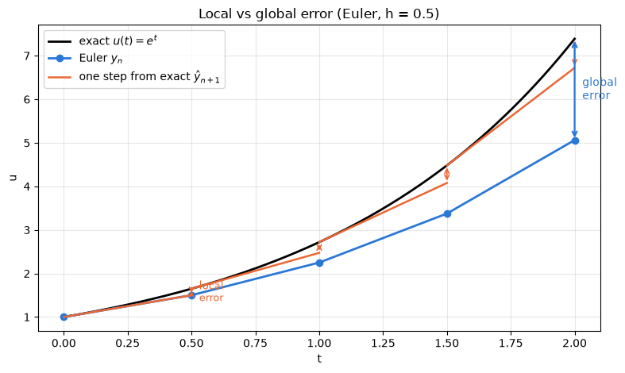

```python
# 1) picture: what local vs global error means  (u' = u, big h so you can see it)
# ============================================================================
fs = lambda t, u: u                    # scalar test problem u' = u, u(0) = 1
h_big, T_big = 0.5, 2.0
tt = np.linspace(0, T_big, 200)

fig, ax = plt.subplots(figsize=(8, 4.8))
ax.plot(tt, np.exp(tt), "k-", lw=2, label="exact $u(t)=e^t$")

# Euler polygon (global)
t, y = 0.0, 1.0
T_pts, Y_pts = [t], [y]
for n in range(int(T_big / h_big)):
    y = y + h_big * fs(t, y); t += h_big
    T_pts.append(t); Y_pts.append(y)
ax.plot(T_pts, Y_pts, "o-", color="#2a78d6", lw=2, ms=6, label="Euler $y_n$")

# local error segments: one Euler step started ON the exact curve
for n, tn in enumerate(T_pts[:-1]):
    un = np.exp(tn)
    y_hat = un + h_big * fs(tn, un)
    ax.plot([tn, tn + h_big], [un, y_hat], "-", color="#eb6834", lw=1.8,
            label="one step from exact $\\hat{y}_{n+1}$" if n == 0 else None)
    ax.annotate("", xy=(tn + h_big, np.exp(tn + h_big)), xytext=(tn + h_big, y_hat),
                arrowprops=dict(arrowstyle="<->", color="#eb6834", lw=1.2))
ax.annotate("", xy=(T_pts[-1], np.exp(T_pts[-1])), xytext=(T_pts[-1], Y_pts[-1]),
            arrowprops=dict(arrowstyle="<->", color="#2a78d6", lw=1.6))
ax.text(T_pts[-1] + 0.03, 0.5 * (np.exp(T_pts[-1]) + Y_pts[-1]), "global\nerror", color="#2a78d6", va="center")
ax.text(T_pts[1] + 0.03, 0.5 * (np.exp(T_pts[1]) + (1 + h_big)), "local\nerror", color="#eb6834", va="center", fontsize=9)
ax.set_xlabel("t"); ax.set_ylabel("u"); ax.set_title(f"Local vs global error (Euler, h = {h_big})")
ax.legend(loc="upper left"); ax.grid(alpha=0.3)
plt.tight_layout(); plt.show()
```

```
Euler
       h    max local  local/h^2  local/h^3    global(T)   global/h  global/h^2
  0.4000    7.965e-02      0.498      1.244    1.482e+00      3.705       9.262
  0.2000    1.998e-02      0.499      2.497    6.382e-01      3.191      15.955
  0.1000    4.999e-03      0.500      4.999    2.831e-01      2.831      28.305
  0.0500    1.250e-03      0.500      9.999    1.330e-01      2.661      53.218
  0.0250    3.125e-04      0.500     20.000    6.448e-02      2.579     103.172
  0.0125    7.812e-05      0.500     40.000    3.174e-02      2.539     203.149

Heun (RK2)
       h    max local  local/h^2  local/h^3    global(T)   global/h  global/h^2
  0.4000    1.063e-02      0.066      0.166    1.298e-01      0.325       0.811
  0.2000    1.332e-03      0.033      0.167    3.339e-02      0.167       0.835
  0.1000    1.666e-04      0.017      0.167    8.334e-03      0.083       0.833
  0.0500    2.083e-05      0.008      0.167    2.083e-03      0.042       0.833
  0.0250    2.604e-06      0.004      0.167    5.208e-04      0.021       0.833
  0.0125    3.255e-07      0.002      0.167    1.302e-04      0.010       0.833
Euler        observed order: local ≈ 2.00, global ≈ 1.02
Heun (RK2)   observed order: local ≈ 3.00, global ≈ 2.00
```

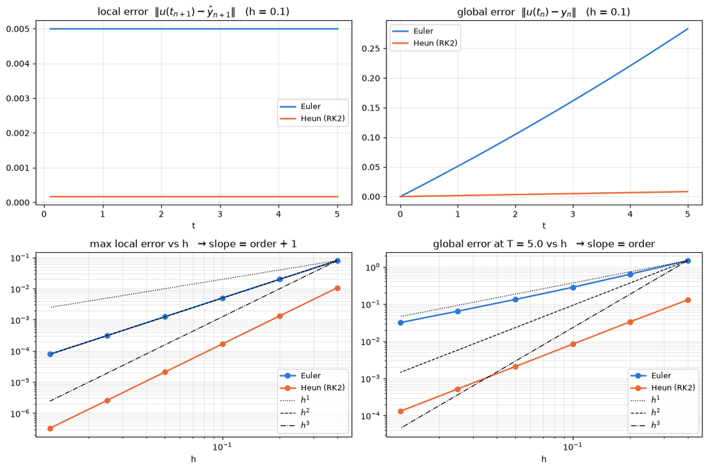

```python
# 2) measure both errors vs h, for Euler and Heun
# ============================================================================
T = 5.0
hs = np.array([0.4, 0.2, 0.1, 0.05, 0.025, 0.0125])
methods = {"Euler": (Phi_euler, "#2a78d6"), "Heun (RK2)": (Phi_heun, "#eb6834")}

results = {}
for name, (Phi, c) in methods.items():
    loc_max, glob_T = [], []
    for h in hs:
        _, le = local_errors(Phi, f, u_exact, h, T)
        _, ge = global_errors(Phi, f, u_exact, u0, h, T)
        loc_max.append(le.max()); glob_T.append(ge[-1])
    results[name] = (np.array(loc_max), np.array(glob_T))

    print(f"\n{name}")
    print(f"{'h':>8} {'max local':>12} {'local/h^2':>10} {'local/h^3':>10} {'global(T)':>12} {'global/h':>10} {'global/h^2':>11}")
    for h, l, g in zip(hs, *results[name]):
        print(f"{h:8.4f} {l:12.3e} {l/h**2:10.3f} {l/h**3:10.3f} {g:12.3e} {g/h:10.3f} {g/h**2:11.3f}")

# observed orders from the last two refinements
for name, (l, g) in results.items():
    p_loc = np.log(l[-2] / l[-1]) / np.log(2); p_glob = np.log(g[-2] / g[-1]) / np.log(2)
    print(f"{name:12s} observed order: local ≈ {p_loc:.2f}, global ≈ {p_glob:.2f}")

# ---- plots: error along t for one h, and convergence in h ------------------
h_show = 0.1
fig, ax = plt.subplots(2, 2, figsize=(12, 8))

for name, (Phi, c) in methods.items():
    tl, le = local_errors(Phi, f, u_exact, h_show, T)
    tg, ge = global_errors(Phi, f, u_exact, u0, h_show, T)
    ax[0, 0].plot(tl, le, color=c, lw=1.8, label=name)
    ax[0, 1].plot(tg, ge, color=c, lw=1.8, label=name)
    l, g = results[name]
    ax[1, 0].loglog(hs, l, "o-", color=c, lw=1.8, label=name)
    ax[1, 1].loglog(hs, g, "o-", color=c, lw=1.8, label=name)

# reference slopes
for p, ls in [(1, ":"), (2, "--"), (3, "-.")]:
    ax[1, 0].loglog(hs, results["Euler"][0][0] * (hs / hs[0])**p, "k" + ls, lw=1, label=f"$h^{p}$")
    ax[1, 1].loglog(hs, results["Euler"][1][0] * (hs / hs[0])**p, "k" + ls, lw=1, label=f"$h^{p}$")

ax[0, 0].set_title(f"local error  $\\|u(t_{{n+1}}) - \\hat{{y}}_{{n+1}}\\|$   (h = {h_show})")
ax[0, 1].set_title(f"global error  $\\|u(t_n) - y_n\\|$   (h = {h_show})")
ax[1, 0].set_title("max local error vs h   → slope = order + 1")
ax[1, 1].set_title(f"global error at T = {T} vs h   → slope = order")
for a in ax[0]: a.set_xlabel("t")
for a in ax[1]: a.set_xlabel("h"); a.xaxis.set_minor_formatter(plt.NullFormatter())
for a in ax.ravel(): a.grid(alpha=0.3, which="both"); a.legend(fontsize=9)
plt.tight_layout(); plt.show()
```

**Reading the table.** Columns that settle to a constant reveal the order: Euler `local/h²` → 0.500 (exactly $\tfrac12\|u''\| = \tfrac12$ on the unit circle — that's why the local error is a flat line in time) and `global/h` → const; Heun `local/h³` → $1/6$ and `global/h²` → const. In the log-log panels: slopes 2 → 1 for Euler, 3 → 2 for Heun. **Global order = local order − 1.**

## 5. Euler step by step for $u' = u$: $h$, $N$, $y_n$, error

For $u' = u$ Euler is compounding interest: $y_n = (1+h)^n$, so $y_{10} = 1.1^{10} = 2.5937$ vs $e = 2.7183$. Euler stays *below* the exact curve at every step — the tangent underestimates a convex function.

```
Euler for u' = u, u(0) = 1   with h = 0.1, N = 10 steps

  n    t_n   y_n (Euler)  u(t_n) exact      err_n
  0   0.00      1.000000      1.000000   0.000000
  1   0.10      1.100000      1.105171   0.005171
  2   0.20      1.210000      1.221403   0.011403
  3   0.30      1.331000      1.349859   0.018859
  4   0.40      1.464100      1.491825   0.027725
  5   0.50      1.610510      1.648721   0.038211
  6   0.60      1.771561      1.822119   0.050558
  7   0.70      1.948717      2.013753   0.065036
  8   0.80      2.143589      2.225541   0.081952
  9   0.90      2.357948      2.459603   0.101655
 10   1.00      2.593742      2.718282   0.124539
```

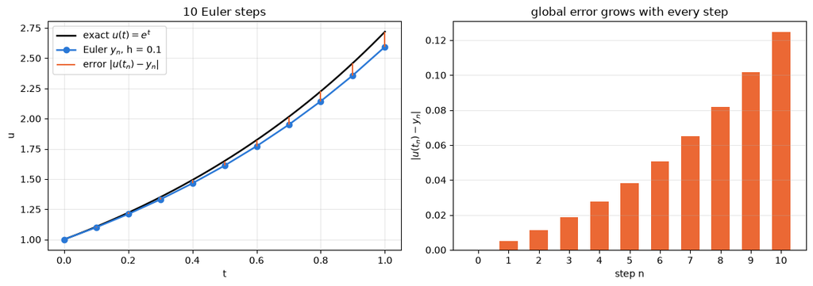

```python
# test problem:  u' = u,  u(0) = 1   ->  u(t) = e^t
def f(t, u):
    return u

def u_exact(t):
    return np.exp(t)

t0, u0, T = 0.0, 1.0, 1.0

def euler_table(h):
    """returns arrays n, t_n, y_n, u(t_n), err_n for N = T/h steps"""
    N = int(round((T - t0) / h))
    t, y = t0, u0
    rows = [(0, t, y, u_exact(t), 0.0)]
    for n in range(1, N + 1):
        y = y + h * f(t, y)
        t = t + h
        rows.append((n, t, y, u_exact(t), abs(u_exact(t) - y)))
    return np.array(rows).T          # columns -> separate arrays

# ---------------------------------------------------------------- 1) N = 10 steps, step by step
h = 0.1
n, t, y, u, err = euler_table(h)

print(f"Euler for u' = u, u(0) = 1   with h = {h}, N = {int(n[-1])} steps\n")
print(f"{'n':>3} {'t_n':>6} {'y_n (Euler)':>13} {'u(t_n) exact':>13} {'err_n':>10}")
for row in zip(n, t, y, u, err):
    print(f"{int(row[0]):3d} {row[1]:6.2f} {row[2]:13.6f} {row[3]:13.6f} {row[4]:10.6f}")

fig, (ax1, ax2) = plt.subplots(1, 2, figsize=(12, 4.3))
tt = np.linspace(t0, T, 200)
ax1.plot(tt, u_exact(tt), "k-", lw=1.8, label="exact $u(t) = e^t$")
ax1.plot(t, y, "o-", color="#2a78d6", lw=1.8, ms=6, label=f"Euler $y_n$, h = {h}")
ax1.vlines(t, y, u, color="#eb6834", lw=1.5, label="error $|u(t_n) - y_n|$")
ax1.set_xlabel("t"); ax1.set_ylabel("u"); ax1.set_title(f"{int(n[-1])} Euler steps"); ax1.legend(); ax1.grid(alpha=0.3)

ax2.bar(n, err, color="#eb6834", width=0.6)
ax2.set_xlabel("step n"); ax2.set_ylabel("$|u(t_n) - y_n|$"); ax2.set_title("global error grows with every step")
ax2.set_xticks(n); ax2.grid(alpha=0.3, axis="y")
plt.tight_layout(); plt.show()
```

```
Error at T = 1.0 (exact e = 2.718282) when h is halved:

       h      N        y_N        err    err/h
 0.10000     10   2.593742   0.124539   1.2454
 0.05000     20   2.653298   0.064984   1.2997
 0.02500     40   2.685064   0.033218   1.3287
 0.01250     80   2.701485   0.016797   1.3438
 0.00625    160   2.709836   0.008446   1.3514
 0.00313    320   2.714047   0.004235   1.3553
 0.00156    640   2.716161   0.002121   1.3572
```

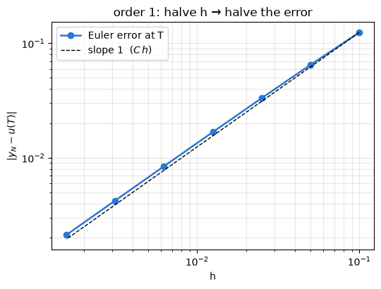

```python
# ---------------------------------------------------------------- 2) halve h: error at T = 1 vs h, N
print(f"\nError at T = {T} (exact e = {np.e:.6f}) when h is halved:\n")
print(f"{'h':>8} {'N':>6} {'y_N':>10} {'err':>10} {'err/h':>8}")
hs, errs = [], []
for k in range(7):
    h = 0.1 / 2**k
    n, t, y, u, err = euler_table(h)
    hs.append(h); errs.append(err[-1])
    print(f"{h:8.5f} {int(n[-1]):6d} {y[-1]:10.6f} {err[-1]:10.6f} {err[-1]/h:8.4f}")

fig, ax = plt.subplots(figsize=(5.5, 4.2))
ax.loglog(hs, errs, "o-", color="#2a78d6", lw=1.8, label="Euler error at T")
ax.loglog(hs, np.array(hs) * errs[0] / hs[0], "k--", lw=1, label="slope 1  ($C\\,h$)")
ax.set_xlabel("h"); ax.set_ylabel("$|y_N - u(T)|$"); ax.set_title("order 1: halve h → halve the error")
ax.xaxis.set_minor_formatter(plt.NullFormatter()); ax.legend(); ax.grid(alpha=0.3, which="both")
plt.tight_layout(); plt.show()
```

Halving $h$ halves the error at $T$: `err/h` settles to $C \approx 1.36$ (theory $C = e/2 = 1.359$). That constant ratio **is** the statement "order 1".

## 6. Richardson extrapolation

If a method has order $p$, the error has an expansion $y_h(T) = u(T) + C h^p + O(h^{p+1})$. Run it twice, with $h$ and $h/2$, and eliminate $C$:

$$R = \frac{2^p\,y_{h/2} - y_h}{2^p - 1} = u(T) + O(h^{p+1})$$

Euler ($p = 1$): $R = 2y_{h/2} - y_h$ — one order gained per extrapolation, repeatable (Romberg table). With the numbers above: $2\cdot 2.653298 - 2.593742 = 2.712854$, error $0.0054$ instead of $0.065$.

Two by-products that need **no exact solution**:

- **error estimate:** $u(T) - y_{h/2} \approx \dfrac{y_{h/2} - y_h}{2^p - 1}$ — the basis of adaptive step-size control;
- **order estimate:** $p \approx \log_2 \dfrac{y_h - y_{h/2}}{y_{h/2} - y_{h/4}}$ — how you check a code's order in practice.

```
y_h      (h=0.1)   = 2.593742   err = 0.124539
y_h/2    (h=0.05)  = 2.653298   err = 0.064984
R = 2*y_h/2 - y_h  = 2.712853   err = 0.005429   <- 12x better than y_h/2
error estimate for y_h/2 = 0.059555   (true 0.064984)

errors |value - e| :
       h   Euler O(h)  1x extrap O(h^2)  2x extrap O(h^3)  3x extrap O(h^4)
 0.10000     1.25e-01          5.43e-03         1.26e-04         1.51e-06
 0.05000     6.50e-02          1.45e-03         1.71e-05         1.03e-07
 0.02500     3.32e-02          3.76e-04         2.23e-06         6.73e-09
 0.01250     1.68e-02          9.56e-05         2.84e-07
 0.00625     8.45e-03          2.41e-05
 0.00313     4.24e-03

observed order from y_h, y_h/2, y_h/4:  p ≈ log2((y_h - y_h/2)/(y_h/2 - y_h/4)) = 0.907
```

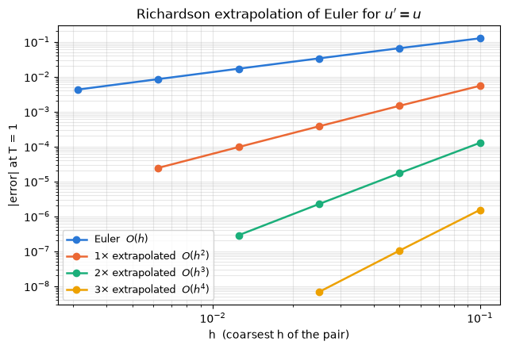

```python
# u' = u, u(0) = 1, T = 1  ->  u(T) = e
def euler_T(h, T=1.0, u0=1.0):
    y = u0
    for n in range(int(round(T / h))):
        y = y + h * y
    return y

exact = np.e
p = 1                                            # order of Euler

# ---------------------------------------------------------------- 1) one extrapolation step
h = 0.1
y_h, y_h2 = euler_T(h), euler_T(h / 2)
R = (2**p * y_h2 - y_h) / (2**p - 1)             # = 2*y_h2 - y_h for p = 1
err_est = (y_h2 - y_h) / (2**p - 1)              # error estimate WITHOUT knowing the exact solution

print(f"y_h      (h={h})   = {y_h:.6f}   err = {abs(exact - y_h):.6f}")
print(f"y_h/2    (h={h/2})  = {y_h2:.6f}   err = {abs(exact - y_h2):.6f}")
print(f"R = 2*y_h/2 - y_h  = {R:.6f}   err = {abs(exact - R):.6f}   <- {abs(exact-y_h2)/abs(exact-R):.0f}x better than y_h/2")
print(f"error estimate for y_h/2 = {err_est:.6f}   (true {exact - y_h2:.6f})")

# ---------------------------------------------------------------- 2) repeat: extrapolation table (Romberg-style)
hs = [0.1 / 2**k for k in range(6)]
Y = [euler_T(h) for h in hs]

table = [Y]                                      # column 0: plain Euler
for level in range(1, 4):                        # column k: k-fold extrapolated, order k+1
    prev = table[-1]
    q = 2**(p + level - 1)                       # error of previous column is O(h^(p+level-1))
    table.append([(q * prev[i + 1] - prev[i]) / (q - 1) for i in range(len(prev) - 1)])

print("\nerrors |value - e| :")
print(f"{'h':>8} {'Euler O(h)':>12} {'1x extrap O(h^2)':>17} {'2x extrap O(h^3)':>17} {'3x extrap O(h^4)':>17}")
for i, h in enumerate(hs):
    cells = [f"{abs(table[k][i] - exact):17.2e}" if i < len(table[k]) else f"{'':>17}" for k in range(4)]
    print(f"{h:8.5f} {cells[0][5:]:>12} {''.join(cells[1:])}")

# ---------------------------------------------------------------- 3) estimate the ORDER from three runs (no exact solution needed)
y1, y2, y4 = euler_T(0.1), euler_T(0.05), euler_T(0.025)
p_est = np.log2((y1 - y2) / (y2 - y4))
print(f"\nobserved order from y_h, y_h/2, y_h/4:  p ≈ log2((y_h - y_h/2)/(y_h/2 - y_h/4)) = {p_est:.3f}")

# ---------------------------------------------------------------- plot
fig, ax = plt.subplots(figsize=(6.5, 4.5))
colors = ["#2a78d6", "#eb6834", "#1baf7a", "#eda100"]
labels = ["Euler  $O(h)$", "1× extrapolated  $O(h^2)$", "2× extrapolated  $O(h^3)$", "3× extrapolated  $O(h^4)$"]
for k in range(4):
    hk = hs[:len(table[k])]
    ax.loglog(hk, np.abs(np.array(table[k]) - exact), "o-", color=colors[k], lw=1.8, label=labels[k])
ax.set_xlabel("h  (coarsest h of the pair)"); ax.set_ylabel("|error| at T = 1")
ax.set_title("Richardson extrapolation of Euler for $u'=u$")
ax.xaxis.set_minor_formatter(plt.NullFormatter()); ax.legend(fontsize=9); ax.grid(alpha=0.3, which="both")
plt.tight_layout(); plt.show()
```

## 7. Infection models — SIR

Compartment models divide the population by disease status. The most basic one is **SIR**:

- **S** — susceptible: not infected, but at risk
- **I** — infected: currently infectious, can transmit to susceptibles
- **R** — recovered: immune (or removed)

$$ \begin{aligned} S' &= -\alpha\, S I \\ I' &= \phantom{-}\alpha\, S I - \beta\, I \\ R' &= \phantom{-\alpha SI\;} +\beta\, I \end{aligned} $$

$\alpha$ = infection rate, $\beta$ = recovery rate, $1/\beta$ = mean infectious period.

**Invariant.** $S' + I' + R' = 0 \Rightarrow N = S + I + R = $ const. Euler preserves this *exactly*: the invariant is linear and the three updates sum to zero (unlike the quadratic energy in Section 3).

**Threshold.** $I' = (\alpha S - \beta)\,I$: infections grow while $S > \beta/\alpha$. The **basic reproduction number** $R_0 = \alpha S_0/\beta$ decides: $R_0 > 1$ epidemic, $R_0 < 1$ dies out. $I$ peaks exactly when $S = \beta/\alpha$, and $1 - \beta/\alpha$ is the herd-immunity threshold.

```
basic reproduction number R0 = alpha*S0/beta = 4.9  (epidemic)
invariant N = S+I+R : min 1.000000000000, max 1.000000000000   (Euler conserves it exactly)
peak of infection    : I = 0.483 at t = 15.5 days;  S at peak = 0.197  (theory: beta/alpha = 0.20)
final size           : S(inf) = 0.007, R(inf) = 0.993  -> 99 % got infected overall
```

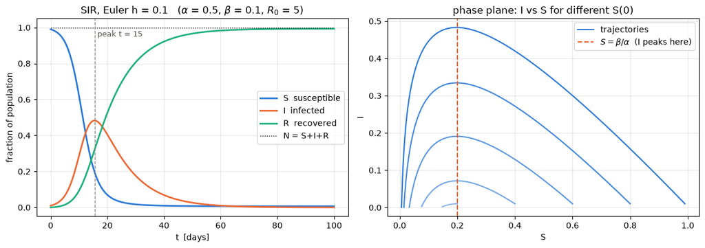

```python
# ---------------------------------------------------------------- SIR model
def f(t, u, alpha, beta):
    S, I, R = u
    return np.array([-alpha * S * I,
                      alpha * S * I - beta * I,
                                      beta * I])

# parameters (population normalised to N = 1, time in days)
alpha = 0.5          # infection rate  [1/day]
beta  = 0.1          # recovery rate   [1/day]   -> mean infectious period 1/beta = 10 days
u0    = np.array([0.99, 0.01, 0.0])               # 1 % infected at t = 0
T, h  = 100.0, 0.1

R0 = alpha * u0[0] / beta
print(f"basic reproduction number R0 = alpha*S0/beta = {R0:.1f}  ({'epidemic' if R0 > 1 else 'dies out'})")

# ---------------------------------------------------------------- Euler
def euler(f, u0, h, T, *args):
    N = int(round(T / h))
    t, u = 0.0, u0.copy()
    ts, us = [t], [u.copy()]
    for n in range(N):
        u = u + h * f(t, u, *args)
        t = t + h
        ts.append(t); us.append(u.copy())
    return np.array(ts), np.array(us)

t, u = euler(f, u0, h, T, alpha, beta)
S, I, R = u.T

# ---------------------------------------------------------------- checks
N_t = S + I + R
i_peak = np.argmax(I)
print(f"invariant N = S+I+R : min {N_t.min():.12f}, max {N_t.max():.12f}   (Euler conserves it exactly)")
print(f"peak of infection    : I = {I[i_peak]:.3f} at t = {t[i_peak]:.1f} days;  S at peak = {S[i_peak]:.3f}  (theory: beta/alpha = {beta/alpha:.2f})")
print(f"final size           : S(inf) = {S[-1]:.3f}, R(inf) = {R[-1]:.3f}  -> {100*R[-1]:.0f} % got infected overall")

# ---------------------------------------------------------------- plot
fig, (ax1, ax2) = plt.subplots(1, 2, figsize=(12, 4.3))

ax1.plot(t, S, color="#2a78d6", lw=2, label="S  susceptible")
ax1.plot(t, I, color="#eb6834", lw=2, label="I  infected")
ax1.plot(t, R, color="#1baf7a", lw=2, label="R  recovered")
ax1.plot(t, N_t, "k:", lw=1, label="N = S+I+R")
ax1.axvline(t[i_peak], color="#8a8984", ls="--", lw=1)
ax1.text(t[i_peak] + 1, 0.95, f"peak t = {t[i_peak]:.0f}", color="#52514e", fontsize=9)
ax1.set_xlabel("t  [days]"); ax1.set_ylabel("fraction of population")
ax1.set_title(f"SIR, Euler h = {h}   ($\\alpha$ = {alpha}, $\\beta$ = {beta}, $R_0$ = {R0:.0f})")
ax1.legend(); ax1.grid(alpha=0.3)

# phase plane S–I: every trajectory is a curve, S(t) decreases, I peaks when S = beta/alpha
for S0 in [0.99, 0.8, 0.6, 0.4, 0.2]:
    _, uu = euler(f, np.array([S0, 0.01, 1 - S0 - 0.01]), h, T, alpha, beta)
    ax2.plot(uu[:, 0], uu[:, 1], color="#2a78d6", lw=1.6, alpha=0.4 + 0.6 * S0, label="trajectories" if S0 == 0.99 else None)
ax2.axvline(beta / alpha, color="#eb6834", ls="--", lw=1.5, label=r"$S = \beta/\alpha$  (I peaks here)")
ax2.set_xlabel("S"); ax2.set_ylabel("I"); ax2.set_title("phase plane: I vs S for different S(0)")
ax2.legend(); ax2.grid(alpha=0.3)
plt.tight_layout(); plt.show()
```

**What to see.** $N$ is conserved to machine precision; the peak occurs at $S = 0.197 \approx \beta/\alpha = 0.2$; in the phase plane *every* trajectory peaks on the same vertical line whatever $S(0)$ is. With $R_0 \approx 5$, 99 % of the population is eventually infected — the final-size relation $\ln(S_\infty/S_0) = R_0 (S_\infty - 1)$.

Related: the **logistic model** $u' = \alpha u(1 - u/K)$ — the SIS variant of this model ($S = N - I$) is exactly logistic. Worked out, fitted to 100 years of world-population data (Euler inside Levenberg–Marquardt), with sensitivity analysis, in `../modeling/00-extra.ipynb`.

## 8. Day 2 in one table

| question | answer | where |
| --- | --- | --- |
| Does a solution exist? | $f$ continuous ⇒ yes, for *some* time (Peano) | §1: $u' = u^2$ lives only until $t = 1/u_0$ |
| Is it unique? | $f$ Lipschitz in $u$ ⇒ yes (Picard–Lindelöf) | §2: $u' = \sqrt u$ has two solutions |
| For how long? | Lipschitz + linear growth bound ⇒ forever | §1 vs $u' = u$ |
| How wrong is Euler? | local $O(h^2)$, global $O(h)$; order = local − 1 | §4, §5 |
| Can I do better cheaply? | Richardson: $2y_{h/2} - y_h$ gains one order; also estimates the error | §6 |
| Does Euler respect structure? | linear invariants yes ($N$ in SIR); quadratic ones no (energy ×$(1+h^2)$/step) | §3, §7 |